| title: “01. Data Import and Basics” |
| --- |
| output: |
| html_document: |
| code_folding: hide |

# KN7001 Neurochemistry with Molecular Neurobiology

R is a **free** and **open-source** programming language frequently used for **data science, statistical analysis, and data visualization**. Whether you are working with small or large datasets, R offers powerful tools for processing, analyzing and visualizing data.

R is versatile and can be applied to a wide range of tasks—from **plotting** a few data points to performing advanced analyses on **transcriptomic** and **genomic data**. In this tutorial, we will demonstrate basic usage of R for **data analysis, statistics, and visualization**.

One of R’s strengths comes from its vast ecosystem of **packages** (or libraries) written by the R community. These packages make many data analysis and visualization tasks easier. Additionally, R has an active **community** and numerous forums where you can find solutions to common issues or ask questions about specific problems.

# Notebook 1: Importing Data & Basics

## In this notebook you will:

- Understand your working directory and set up a simple project.
- Learn what vectors and data frames are in R.
- Import a CSV file.
- Peek at your data and compute simple summaries.
- Practice subsetting (a.k.a. “slicing”) data.
- Learn simple data vizualisation in base R

## Interface

Data analysis in R is typically done in an IDE (Integrated Development Environment). The most widely used IDE for R is RStudio, which can be downloaded here: [RStudio IDE](https://posit.co/products/open-source/rstudio/).

[figure not shown]

RStudio Logo

### **Prerequisite:** Install both R and RStudio on your computer before proceeding.

For detailed instruction follow the guide [here](https://rstudio-education.github.io/hopr/starting.html)

#### Create notebook like this:

[figure not shown]

image

R notebooks allow for mixing of notes or explanations, R code and figures in a single document and are super convenient for documentation and sharing.

You can delete lines 6-20 in the new notebook.

New, empty code chunk can be created using **cmd+option+I** (Mac) or **ctrl+alt+I** (Windows) or clicking **Code -> Insert Chunk**

Code chunks are highlighted in grey and contain only code. You can write notes outside of code chunks

outputs of functions or images appear below the code chunks

Now the notebook is ready to start our analysis

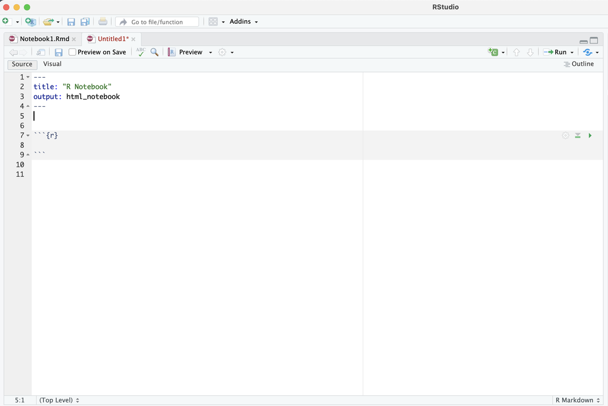

empty_notebook

In this tutorial: - Instructions are provided as regular text. - Code is shown inside grey boxes, which you can copy and paste directly into your RStudio session.

**Note:** Some code blocks might require minor edits based on your file paths or environment.

````r
# This is a code block
# It starts with ```{r} and ends with ```
# Lines that start with "#" are comments in R. These lines are ignored when the code is executed.
````

## Part A — R Objects 101: Vectors & Data Frames

Understanding two core building blocks of R

## Vectors

### What is a vector?

A vector is the most basic data container in R: an ordered list of values all of the same type.

Common types: numeric (e.g., 1.2), integer (e.g., 5L), logical (TRUE/FALSE), character (text), factor (categorical).

Create with c() (“combine”).

```r
# Numeric vector
lengths_um <- c(12.3, 15.8, 9.4, 18.1)
print(lengths_um)
```

```
## [1] 12.3 15.8  9.4 18.1
```

```r
# Character vector
conditions <- c("control", "condition_1", "condition_2")
print(conditions)
```

```
## [1] "control"     "condition_1" "condition_2"
```

```r
# Logical vector (TRUE/FALSE)
keepers <- c(TRUE, FALSE, TRUE, TRUE)
print(keepers)
```

```
## [1]  TRUE FALSE  TRUE  TRUE
```

```r
# We can apply functions to vectors
length(lengths_um)      # how many elements?
```

```
## [1] 4
```

```r
class(lengths_um)       # what type?
```

```
## [1] "numeric"
```

### Vectorization: apply operations to whole vectors

```r
# In R, most operators and many functions are *vectorized*:
# they act on every element of a vector without writing a loop.

# Example vector
lengths_um <- c(12.3, 15.8, 9.4, 18.1)
```

#### Elementwise arithmetic with a single number (scalar)

```r
lengths_um + 3      # add 3 to every element
```

```
## [1] 15.3 18.8 12.4 21.1
```

```r
lengths_um * 5      # multiply every element by 5
```

```
## [1] 61.5 79.0 47.0 90.5
```

```r
lengths_um / 2      # divide every element by 2
```

```
## [1] 6.15 7.90 4.70 9.05
```

```r
lengths_um ^ 2      # square each element
```

```
## [1] 151.29 249.64  88.36 327.61
```

```r
# Elementwise arithmetic with another vector (same length)
noise <- c(0.5, -0.2, 0.0, 1.1)
lengths_um + noise
```

```
## [1] 12.8 15.6  9.4 19.2
```

```r
lengths_um - noise
```

```
## [1] 11.8 16.0  9.4 17.0
```

#### Recycling rule:

```r
# If lengths are compatible (e.g., 4 and 2), R "recycles" the shorter vector.
adjust <- c(-1, +1)
lengths_um + adjust    # adds -1, +1, -1, +1 to the four elements in turn
```

```
## [1] 11.3 16.8  8.4 19.1
```

```r
# ⚠️ If lengths aren't multiples, R still recycles but issues a warning.
odd <- c(1, 2, 3)
lengths_um + odd       # expect a warning; avoid this pattern
```

```
## [1] 13.3 17.8 12.4 19.1
```

### Vectorized math functions (operate on each element)

```r
log10(lengths_um)
```

```
## [1] 1.0899051 1.1986571 0.9731279 1.2576786
```

```r
sqrt(lengths_um)
```

```
## [1] 3.507136 3.974921 3.065942 4.254409
```

```r
round(lengths_um,digits = 0)
```

```
## [1] 12 16  9 18
```

```r
# Vectorized summaries and cumulative ops
mean(lengths_um)               # single-number summary
```

```
## [1] 13.9
```

```r
cumsum(lengths_um)             # running sum
```

```
## [1] 12.3 28.1 37.5 55.6
```

```r
range(lengths_um)              # min and max
```

```
## [1]  9.4 18.1
```

```r
# Vectorized comparisons and logical operations
lengths_um > 12                # elementwise comparison → logical vector
```

```
## [1]  TRUE  TRUE FALSE  TRUE
```

```r
which(lengths_um > 12)        # indices where condition is TRUE
```

```
## [1] 1 2 4
```

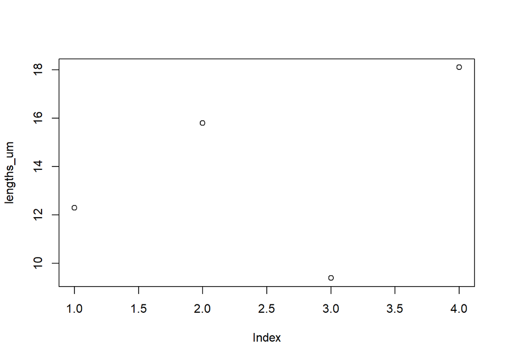

```r
# Plotting is also vectorised
plot(lengths_um)
```

### Exercises:

1. Increase length values of *lengths_um* by 10% (e.g., expected growth).
2. Apply a microscope calibration: multiply each value of *lengths_um* by a scale factor 0.98 and subtract a blank offset of 0.15 µm.
3. Return the indices (and values) where the calibrated lengths are > 15 µm.
4. Calculate z-score of lengths_um.

Note: Z-score is a measure of how many standard deviations a value is from the mean of its distribution.

Use formula:

z = (x - μ) / σ

- z: is the z-score
- x: is the raw data point or individual score
- μ: (mu) is the population mean
- σ: (sigma) is the population standard deviation

## Data frames

### What is a data frame?

A data frame is a table (rows × columns). Each column is a vector of equal length; different columns can have different types.

Think of it like an Excel sheet where:

Each column = one variable (e.g., control, condition_1, condition_2).

Each row = one observation (e.g., one well, one cell, one replicate).

```r
# Build a tiny data frame from vectors
df_demo <- data.frame(
  control     = c(0.45, 0.62, 0.51),
  condition_1 = c(0.60, 0.70, 0.66),
  condition_2 = c(0.80, 0.77, 0.83)
)
print(df_demo)
```

```
##   control condition_1 condition_2
## 1    0.45        0.60        0.80
## 2    0.62        0.70        0.77
## 3    0.51        0.66        0.83
```

```r
class(df_demo)     # "data.frame"
```

```
## [1] "data.frame"
```

```r
nrow(df_demo)      # number of rows
```

```
## [1] 3
```

```r
ncol(df_demo)      # number of columns
```

```
## [1] 3
```

```r
dim(df_demo)       # number of rows and columns (dimensions of data frame)
```

```
## [1] 3 3
```

```r
str(df_demo)       # compact structure
```

```
## 'data.frame':    3 obs. of  3 variables:
##  $ control    : num  0.45 0.62 0.51
##  $ condition_1: num  0.6 0.7 0.66
##  $ condition_2: num  0.8 0.77 0.83
```

#### Access columns with $ or [, ]:

```r
df_demo$control           # Access column with $
```

```
## [1] 0.45 0.62 0.51
```

```r
df_demo[ , "control"]     # Access column with [,] and column name
```

```
## [1] 0.45 0.62 0.51
```

```r
df_demo[,1]               # Access column with [,] and column number
```

```
## [1] 0.45 0.62 0.51
```

```r
df_demo[1:2, c("control", "condition_2")]  # rows 1–2, selected columns
```

```
##   control condition_2
## 1    0.45        0.80
## 2    0.62        0.77
```

Why this matters: Many R functions expect vectors (operate on a column), while plotting and modeling functions often expect a data frame (operate on multiple columns together).

## Part B: Load & Inspect Your Data

## Importing the data into R

### Example: Statistical Analysis of Neurite Outgrowth

Neurites are any type of projection/process from the cell body of a neuron and can be differentiated into either dendrites or axons. In this experiment, we measured neurite outgrowth in cell cultures after two different treatments with differentiation factors, along with a control group. The measurements were taken using an automated analysis pipeline, and the results were exported into a CSV file.

We will go through the steps of importing the data, performing basic quality control (QC), visualizing it, and test the data for statistical significance.

### Seting up your first R project

**Note:** General rule for data analysis is to keep the data and code/notebooks separated in different folders.

#### You should end up with the following folders and files:

[figure not shown]

image

### Import a csv

Before we can analyze the data, we need to import it into R and store it in the computer’s memory (RAM). Once imported, we can manipulate, clean, visualize, and perform statistical analysis on the data.

```r
neurites <- read.csv("../../data/03_neurites_synthetic.csv")  # <-- adjust filename if needed
```

### Check that the import went ok

```r
# peek at the first rows
head(neurites)
```

```
##      control condition_1 condition_2
## 1 0.06372999   0.7305269    1.097290
## 2 0.10308265   1.1828578    3.920390
## 3 0.99902660   0.7414197    5.523907
## 4 0.60876101   0.6742225    7.151884
## 5 0.63159041   1.0256576    7.167801
## 6 0.39914599   1.4141315    7.611765
```

```r
# How big is it?
nrow(neurites)
```

```
## [1] 20
```

```r
ncol(neurites)
```

```
## [1] 3
```

```r
dim(neurites)
```

```
## [1] 20  3
```

```r
# Column names
colnames(neurites)
```

```
## [1] "control"     "condition_1" "condition_2"
```

```r
# Structure (types and a preview)
str(neurites)
```

```
## 'data.frame':    20 obs. of  3 variables:
##  $ control    : num  0.0637 0.1031 0.999 0.6088 0.6316 ...
##  $ condition_1: num  0.731 1.183 0.741 0.674 1.026 ...
##  $ condition_2: num  1.1 3.92 5.52 7.15 7.17 ...
```

```r
# Summary statistics per column
summary(neurites)
```

```
##     control         condition_1      condition_2
##  Min.   :0.06373   Min.   :0.4107   Min.   : 0.0855
##  1st Qu.:0.36318   1st Qu.:0.8343   1st Qu.: 1.0736
##  Median :0.48962   Median :0.9205   Median : 3.2464
##  Mean   :0.50141   Mean   :0.9314   Mean   : 3.7242
##  3rd Qu.:0.67626   3rd Qu.:1.0401   3rd Qu.: 5.9717
##  Max.   :0.99903   Max.   :1.4141   Max.   :11.1079
```

### Descriptive statistics

```r
mean(neurites$control, na.rm = TRUE)
```

```
## [1] 0.5014132
```

```r
sd(neurites$control, na.rm = TRUE)
```

```
## [1] 0.2651407
```

```r
quantile(neurites$control, probs = c(0.25, 0.5, 0.75), na.rm = TRUE)
```

```
##       25%       50%       75%
## 0.3631805 0.4896172 0.6762599
```

```r
median(neurites$control, na.rm = TRUE)
```

```
## [1] 0.4896172
```

#### Exercise:

- Compute the same statistics (mean, sd, quantiles and median) for the other 2 columns condition_1 and condition_2

```r
# Your code here
```

### Slicing (subsetting) data frames

#### Select single columns

```r
neurites$control
```

```
##  [1] 0.06372999 0.10308265 0.99902660 0.60876101 0.63159041 0.39914599
##  [7] 0.70256457 0.10291603 0.73953168 0.32652134 0.75598748 0.37540024
## [13] 0.50765997 0.66749165 0.54694033 0.40000315 0.96263523 0.23041589
## [19] 0.43328637 0.47157436
```

```r
neurites$condition_1
```

```
##  [1] 0.7305269 1.1828578 0.7414197 0.6742225 1.0256576 1.4141315 0.9060978
##  [8] 0.8720033 0.4106907 1.0834832 0.8610258 0.8805989 1.0126239 1.1345809
## [15] 0.8636573 0.7539411 0.9401939 0.9689116 0.9349642 1.2367565
```

```r
neurites$condition_2
```

```
##  [1]  1.09728997  3.92038951  5.52390681  7.15188387  7.16780066  7.61176463
##  [7]  6.45179316  0.08549482  0.24295711  1.00254557  2.54837793  1.98036598
## [13]  2.81083949 11.10792975  5.81169655  3.68200933  0.28635481  4.71699832
## [19]  1.16517221  0.11931422
```

#### Select column by column number(s)

```r
neurites[ , 1]
```

```
##  [1] 0.06372999 0.10308265 0.99902660 0.60876101 0.63159041 0.39914599
##  [7] 0.70256457 0.10291603 0.73953168 0.32652134 0.75598748 0.37540024
## [13] 0.50765997 0.66749165 0.54694033 0.40000315 0.96263523 0.23041589
## [19] 0.43328637 0.47157436
```

```r
neurites[ , 1:2]
```

```
##       control condition_1
## 1  0.06372999   0.7305269
## 2  0.10308265   1.1828578
## 3  0.99902660   0.7414197
## 4  0.60876101   0.6742225
## 5  0.63159041   1.0256576
## 6  0.39914599   1.4141315
## 7  0.70256457   0.9060978
## 8  0.10291603   0.8720033
## 9  0.73953168   0.4106907
## 10 0.32652134   1.0834832
## 11 0.75598748   0.8610258
## 12 0.37540024   0.8805989
## 13 0.50765997   1.0126239
## 14 0.66749165   1.1345809
## 15 0.54694033   0.8636573
## 16 0.40000315   0.7539411
## 17 0.96263523   0.9401939
## 18 0.23041589   0.9689116
## 19 0.43328637   0.9349642
## 20 0.47157436   1.2367565
```

```r
neurites[ , c(1, 3)]
```

```
##       control condition_2
## 1  0.06372999  1.09728997
## 2  0.10308265  3.92038951
## 3  0.99902660  5.52390681
## 4  0.60876101  7.15188387
## 5  0.63159041  7.16780066
## 6  0.39914599  7.61176463
## 7  0.70256457  6.45179316
## 8  0.10291603  0.08549482
## 9  0.73953168  0.24295711
## 10 0.32652134  1.00254557
## 11 0.75598748  2.54837793
## 12 0.37540024  1.98036598
## 13 0.50765997  2.81083949
## 14 0.66749165 11.10792975
## 15 0.54694033  5.81169655
## 16 0.40000315  3.68200933
## 17 0.96263523  0.28635481
## 18 0.23041589  4.71699832
## 19 0.43328637  1.16517221
## 20 0.47157436  0.11931422
```

#### Select column by it’s name

```r
neurites[,"control"]
```

```
##  [1] 0.06372999 0.10308265 0.99902660 0.60876101 0.63159041 0.39914599
##  [7] 0.70256457 0.10291603 0.73953168 0.32652134 0.75598748 0.37540024
## [13] 0.50765997 0.66749165 0.54694033 0.40000315 0.96263523 0.23041589
## [19] 0.43328637 0.47157436
```

```r
neurites[,c("control","condition_1")]
```

```
##       control condition_1
## 1  0.06372999   0.7305269
## 2  0.10308265   1.1828578
## 3  0.99902660   0.7414197
## 4  0.60876101   0.6742225
## 5  0.63159041   1.0256576
## 6  0.39914599   1.4141315
## 7  0.70256457   0.9060978
## 8  0.10291603   0.8720033
## 9  0.73953168   0.4106907
## 10 0.32652134   1.0834832
## 11 0.75598748   0.8610258
## 12 0.37540024   0.8805989
## 13 0.50765997   1.0126239
## 14 0.66749165   1.1345809
## 15 0.54694033   0.8636573
## 16 0.40000315   0.7539411
## 17 0.96263523   0.9401939
## 18 0.23041589   0.9689116
## 19 0.43328637   0.9349642
## 20 0.47157436   1.2367565
```

```r
t.test(neurites$control,neurites$condition_1, alternative = 'two.sided', paired = FALSE)
```

```
##
##  Welch Two Sample t-test
##
## data:  neurites$control and neurites$condition_1
## t = -5.5659, df = 36.835, p-value = 2.465e-06
## alternative hypothesis: true difference in means is not equal to 0
## 95 percent confidence interval:
##  -0.5865654 -0.2734427
## sample estimates:
## mean of x mean of y
## 0.5014132 0.9314173
```

```r
# For more help on t.test parameters do
?t.test
```

```
## starting httpd help server ... done
```

### Subsetting data frames using logical filters

```r
# Logical filters (TRUE/FALSE vectors)
neurites$control > 0.5 # Vectorised logical comparison
```

```
##  [1] FALSE FALSE  TRUE  TRUE  TRUE FALSE  TRUE FALSE  TRUE FALSE  TRUE FALSE
## [13]  TRUE  TRUE  TRUE FALSE  TRUE FALSE FALSE FALSE
```

```r
neurites[neurites$control > 0.5, ]  # keep rows where control > 0.5
```

```
##      control condition_1 condition_2
## 3  0.9990266   0.7414197   5.5239068
## 4  0.6087610   0.6742225   7.1518839
## 5  0.6315904   1.0256576   7.1678007
## 7  0.7025646   0.9060978   6.4517932
## 9  0.7395317   0.4106907   0.2429571
## 11 0.7559875   0.8610258   2.5483779
## 13 0.5076600   1.0126239   2.8108395
## 14 0.6674916   1.1345809  11.1079297
## 15 0.5469403   0.8636573   5.8116965
## 17 0.9626352   0.9401939   0.2863548
```

```r
neurites[neurites$condition_1 > neurites$control & neurites$condition_2 > neurites$control,] # Keep rows where both condition_1 and condition_2 are greater than control
```

```
##       control condition_1 condition_2
## 1  0.06372999   0.7305269    1.097290
## 2  0.10308265   1.1828578    3.920390
## 4  0.60876101   0.6742225    7.151884
## 5  0.63159041   1.0256576    7.167801
## 6  0.39914599   1.4141315    7.611765
## 7  0.70256457   0.9060978    6.451793
## 10 0.32652134   1.0834832    1.002546
## 11 0.75598748   0.8610258    2.548378
## 12 0.37540024   0.8805989    1.980366
## 13 0.50765997   1.0126239    2.810839
## 14 0.66749165   1.1345809   11.107930
## 15 0.54694033   0.8636573    5.811697
## 16 0.40000315   0.7539411    3.682009
## 18 0.23041589   0.9689116    4.716998
## 19 0.43328637   0.9349642    1.165172
```

#### Exercise:

- Print neurite data frame rows where control is greater than 0.2 and condition_1 is greater than 1

```r
# Your code here
```

### Adding new column

```r
neurites$delta_1 <- neurites$condition_1 - neurites$control
print(neurites)
```

```
##       control condition_1 condition_2     delta_1
## 1  0.06372999   0.7305269  1.09728997  0.66679688
## 2  0.10308265   1.1828578  3.92038951  1.07977515
## 3  0.99902660   0.7414197  5.52390681 -0.25760693
## 4  0.60876101   0.6742225  7.15188387  0.06546153
## 5  0.63159041   1.0256576  7.16780066  0.39406717
## 6  0.39914599   1.4141315  7.61176463  1.01498548
## 7  0.70256457   0.9060978  6.45179316  0.20353325
## 8  0.10291603   0.8720033  0.08549482  0.76908727
## 9  0.73953168   0.4106907  0.24295711 -0.32884094
## 10 0.32652134   1.0834832  1.00254557  0.75696191
## 11 0.75598748   0.8610258  2.54837793  0.10503833
## 12 0.37540024   0.8805989  1.98036598  0.50519869
## 13 0.50765997   1.0126239  2.81083949  0.50496391
## 14 0.66749165   1.1345809 11.10792975  0.46708928
## 15 0.54694033   0.8636573  5.81169655  0.31671696
## 16 0.40000315   0.7539411  3.68200933  0.35393799
## 17 0.96263523   0.9401939  0.28635481 -0.02244134
## 18 0.23041589   0.9689116  4.71699832  0.73849567
## 19 0.43328637   0.9349642  1.16517221  0.50167782
## 20 0.47157436   1.2367565  0.11931422  0.76518211
```

### More independent exercises:

- Use the neurites data frame you loaded earlier unless stated otherwise.
- Tip: str(neurites), names(neurites), and head(neurites) are your friends.
1. Print column names
2. Print data frame dimensions
3. print first 6 rows
4. print column control
5. print all rows that have control value > 0.2
6. For each column calculate it’s mean and standard deviation
7. Challenge: Create a logical column called “is_best2”, which can be either TRUE or FALSE. Make it TRUE if value in column condition_2 is greater than value in both columns control and condition_1

## Plotting

Base R graphics are built in, lightweight, and perfect for fast exploratory plots.

### Histograms

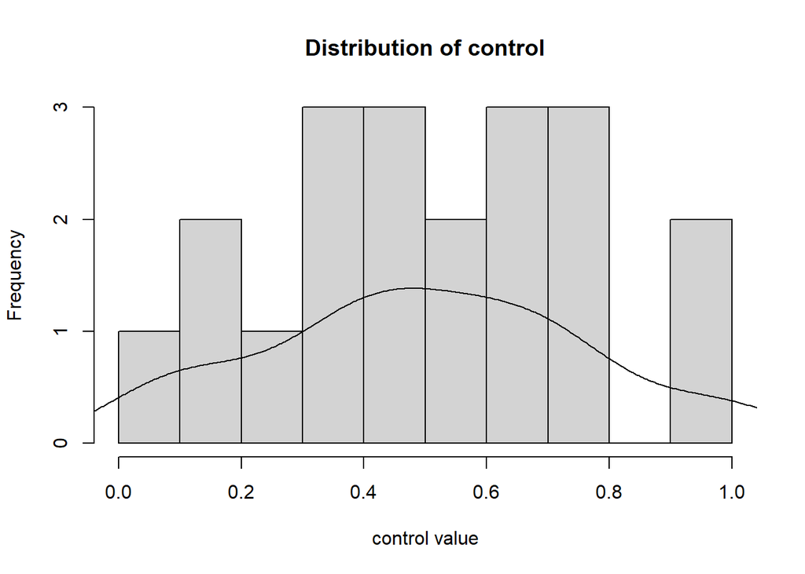

```r
# Histograms
hist(neurites$control,breaks = 10, xlab = 'control value', main = 'Distribution of control')

# Optional - overlay a density curve
d <- density(neurites$control, na.rm = TRUE)
lines(d)
```

#### Exercise:

- plot histograms of condition_1 and condition_2 columns of neurite data frame

### Barplots

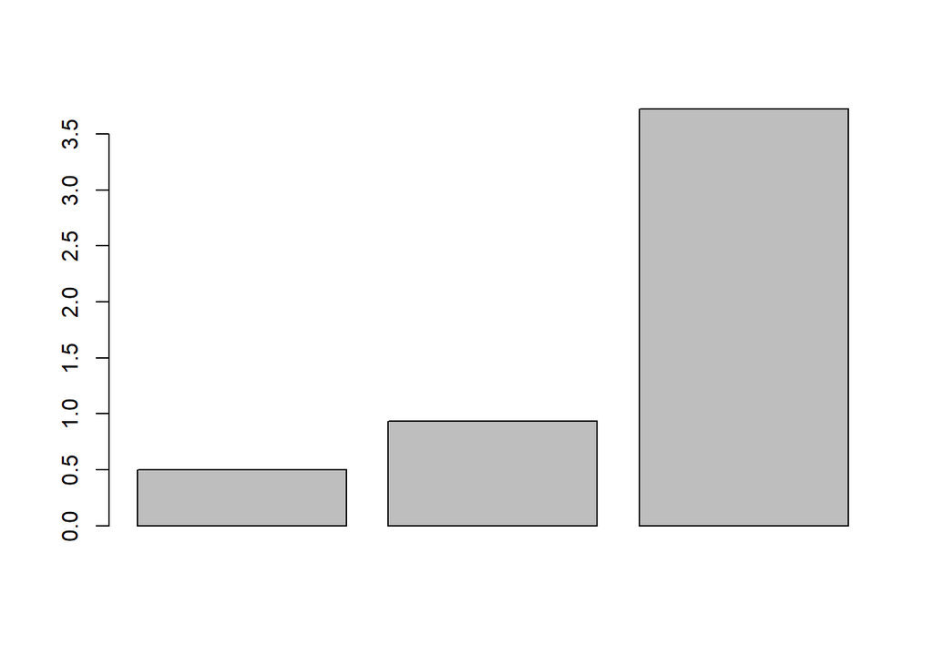

```r
# First let's calculate means of each column

mean_control <- mean(neurites$control)
mean_cond1 <- mean(neurites$condition_1)
mean_cond2 <- mean(neurites$condition_2)

# Now plot the means as a barplot
barplot(c(mean_control,mean_cond1,mean_cond2))
```

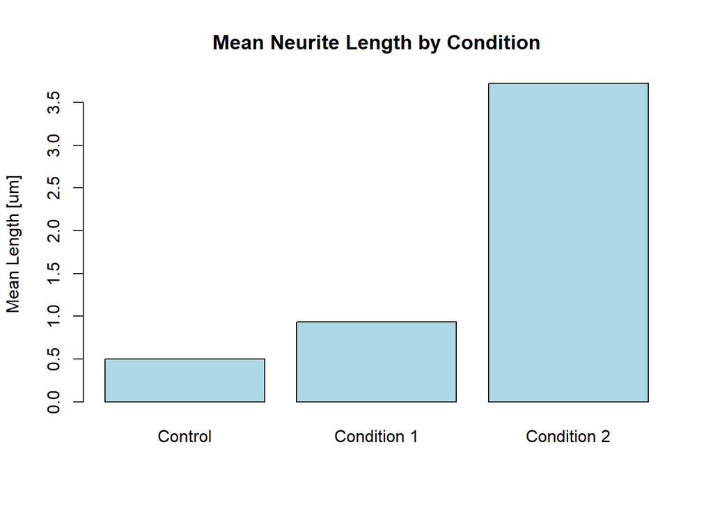

```r
# Create a barplot with axis labels and color
barplot(c(mean_control,mean_cond1,mean_cond2),
        names.arg = c('Control', 'Condition 1', 'Condition 2'),
        col = 'lightblue',
        main = 'Mean Neurite Length by Condition',
        ylab = 'Mean Length [um]')
```

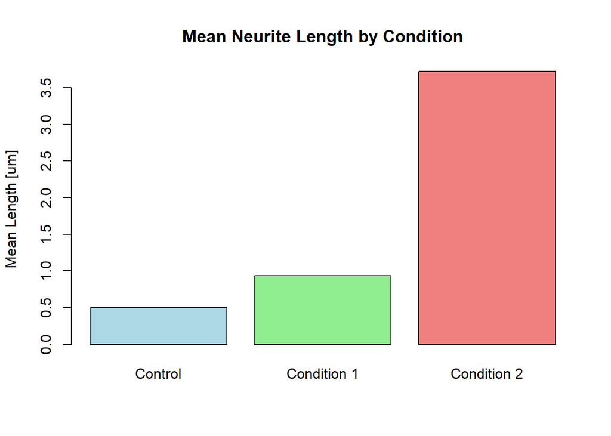

```r
barplot(c(mean_control,mean_cond1,mean_cond2),
        names.arg = c('Control', 'Condition 1', 'Condition 2'),
        col = c('lightblue', 'lightgreen', 'lightcoral'),
        main = 'Mean Neurite Length by Condition',
        ylab = 'Mean Length [um]')
```

### Saving a plot as pdf

```r
# Open a PDF file to save the plot
pdf(file = 'Neurites_plot.pdf', width = 6, height = 4)


# Create the same barplot inside the PDF file
barplot(c(mean_control, mean_cond1, mean_cond2),
        names.arg = c('Control', 'Condition 1', 'Condition 2'),
        col = 'lightblue',
        main = 'Mean Neurite Length by Condition',
        ylab = 'Mean Length [um]')


# Close the PDF device to finish saving the plot
dev.off()
```

### Boxplot (box and whisker plot)

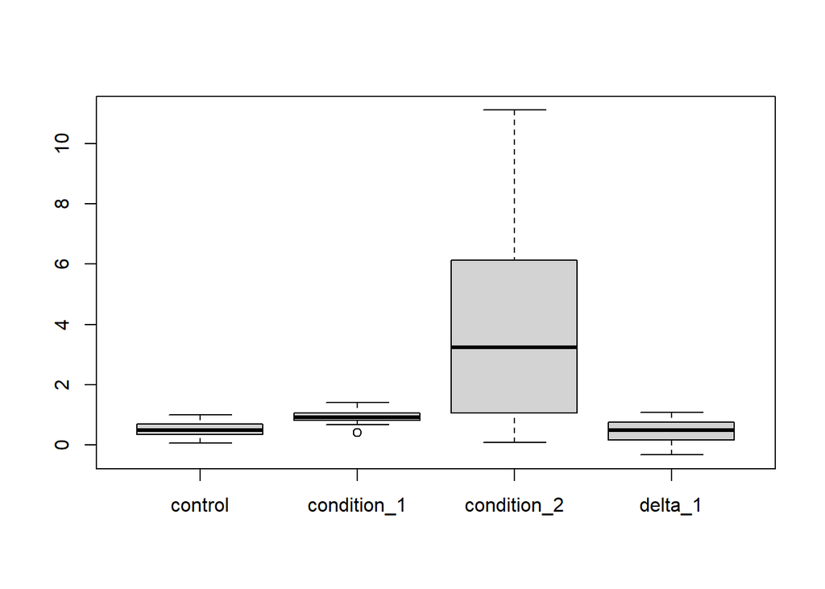

```r
# Boxplot to compare the groups/columns
boxplot(neurites) # neurites is a data frame - each column is one group on x axis
```

#### Exercise:

- plot only 3 columns from neurites data.frame - control, condition_1 and condition_2

## Homework - independent exercises

Perhaps you may need to google a bit to solve these tasks.

1. Create vector v <- c(1, “2”, 3); check class(v). Convert it to a numeric vector.
2. Compute the mean of vector c(1.15, 1.17, 0.83, NA, 1.43, 0.58) with and without na.rm=TRUE parameter. Explain the difference.
3. Rename columns of data frame neurites condition_1 → cond1, condition_2 → cond2 using names().
4. Print rows 10–15 and only columns control and cond2 of neurites data frame.
5. Add logical column is_high_cond2 which will be TRUE if the value in column cond2 is greater than median of the whole column cond2, and FALSE if it is less than the median.
6. Create a vector log_control which is logarithm of neurites$control and plot its histogram.
7. Which row has the largest cond1? Print that row.
8. Count how many rows have cond2 > control.
9. Plot histogram of column delta_1 of df neurites
10. Plot histogram of log normalized values of condition_1